# Bored of sitting at home?

# This is a tutorial on how to make your own coronavirus map in Python.

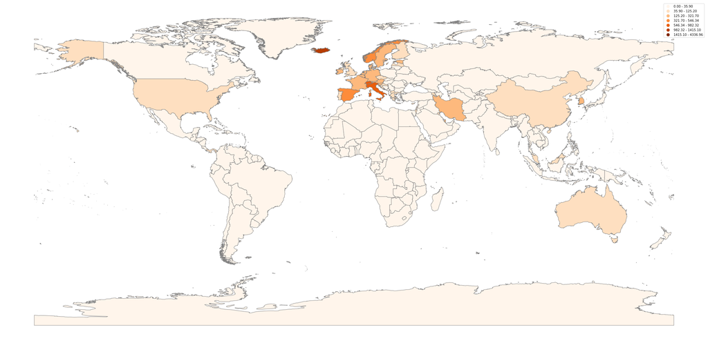

## Stage 0 - idea

Create a choropleth map displaing a ratio of coronavirus cases per one milion people for each country.

(**choropleth** - a map which uses differences in shading, colouring within predefined areas to indicate the average values of a particular quantity in those areas - Google dictionary)

We will need to create a dataset with 2 columns only - **cases per milion people** and **geometry** (shape of each country).

It should look like exactly like this:

```python
example.head()
```

| name | geometry | cases_per_milion |
| --- | --- | --- |
| Azerbaijan | (POLYGON ((45.08332100000001 39.76804400000015... | 5.429063 |
| Albania | POLYGON ((19.436214 41.021065, 19.450554 41.05... | 26.424663 |
| American Samoa | (POLYGON ((-170.542511 -14.29750299999995, -17... | 0.000000 |
| Algeria | POLYGON ((2.96361 36.802216, 2.981389 36.80693... | 3.423135 |
| Angola | (POLYGON ((11.750832 -16.75527999999991, 11.77... | 0.069412 |

Thanks to this form we will be able to plot this dataset in form of choropleth. (scroll down to see the result)

## Stage 1 - data download

We have 3 datasets available:

1. World borders (world_shp)
2. Population accross the world (population)
3. Coronavirus data for each country (world_data_df)

We will start with importing necessary libraries and data download.

```python
import geopandas
import pandas
import numpy as np
import matplotlib.pyplot as plt
from datetime import date

#read all datasets to variables
population = pandas.read_csv('./population.csv') # this file is also available on my github
# this file is also available on my github - you'll have to download all 4 of them - .shp, .shx, .dbf and .prj
world_shp = geopandas.read_file('./TM_WORLD_BORDERS-0.3.shp')
world_data_df = pandas.read_csv('https://raw.githubusercontent.com/CSSEGISandData/COVID-19/master/csse_covid_19_data/csse_covid_19_time_series/time_series_19-covid-Confirmed.csv')

#display world shapefile in tabular form
world_shp.head()
```

|  | fips | iso2 | iso3 | un | name | area | pop2005 | region | subregion | lon | lat | geometry |
| --- | --- | --- | --- | --- | --- | --- | --- | --- | --- | --- | --- | --- |
| 0 | AJ | AZ | AZE | 31 | Azerbaijan | 8260 | 8352021 | 142 | 145 | 47.395 | 40.430 | (POLYGON ((45.08332100000001 39.76804400000015... |
| 1 | AL | AL | ALB | 8 | Albania | 2740 | 3153731 | 150 | 39 | 20.068 | 41.143 | POLYGON ((19.436214 41.021065, 19.450554 41.05... |
| 2 | AQ | AS | ASM | 16 | American Samoa | 20 | 64051 | 9 | 61 | -170.730 | -14.318 | (POLYGON ((-170.542511 -14.29750299999995, -17... |
| 3 | AD | DZ | DZA | 12 | Algeria | 238174 | 32854159 | 2 | 15 | 2.632 | 28.163 | POLYGON ((2.96361 36.802216, 2.981389 36.80693... |
| 4 | AO | AO | AGO | 24 | Angola | 124670 | 16095214 | 2 | 17 | 17.544 | -12.296 | (POLYGON ((11.750832 -16.75527999999991, 11.77... |

This is how raw shapefile looks like, the most important thing is **geometry** column which is responsible for country shapes.

Now let's see other datasets.

```python
#coronavirus cases
world_data_df.head()
```

|  | Province/State | Country/Region | Lat | Long | 1/22/20 | 1/23/20 | 1/24/20 | ... | 3/15/20 | 3/16/20 | 3/17/20 | 3/18/20 | 3/19/20 | 3/20/20 | 3/21/20 |
| --- | --- | --- | --- | --- | --- | --- | --- | --- | --- | --- | --- | --- | --- | --- | --- |
| 0 | NaN | Thailand | 15.0000 | 101.0000 | 2 | 3 | 5 | ... | 114 | 147 | 177 | 212 | 272 | 322 | 411 |
| 1 | NaN | Japan | 36.0000 | 138.0000 | 2 | 1 | 2 | ... | 839 | 825 | 878 | 889 | 924 | 963 | 1007 |
| 2 | NaN | Singapore | 1.2833 | 103.8333 | 0 | 1 | 3 | ... | 226 | 243 | 266 | 313 | 345 | 385 | 432 |
| 3 | NaN | Nepal | 28.1667 | 84.2500 | 0 | 0 | 0 | ... | 1 | 1 | 1 | 1 | 1 | 1 | 1 |
| 4 | NaN | Malaysia | 2.5000 | 112.5000 | 0 | 0 | 0 | ... | 428 | 566 | 673 | 790 | 900 | 1030 | 1183 |

5 rows × 64 columns

```python
#population
population.head()
```

|  | Country | Country_Code | Year_1960 | Year_1961 | Year_1962 | Year_1963 | Year_1964 | ... | Year_2010 | Year_2011 | Year_2012 | Year_2013 | Year_2014 | Year_2015 | Year_2016 |
| --- | --- | --- | --- | --- | --- | --- | --- | --- | --- | --- | --- | --- | --- | --- | --- |
| 0 | Aruba | ABW | 54211.0 | 55438.0 | 56225.0 | 56695.0 | 57032.0 | ... | 101669.0 | 102053.0 | 102577.0 | 103187.0 | 103795.0 | 104341.0 | 104822.0 |
| 1 | Afghanistan | AFG | 8996351.0 | 9166764.0 | 9345868.0 | 9533954.0 | 9731361.0 | ... | 28803167.0 | 29708599.0 | 30696958.0 | 31731688.0 | 32758020.0 | 33736494.0 | 34656032.0 |
| 2 | Angola | AGO | 5643182.0 | 5753024.0 | 5866061.0 | 5980417.0 | 6093321.0 | ... | 23369131.0 | 24218565.0 | 25096150.0 | 25998340.0 | 26920466.0 | 27859305.0 | 28813463.0 |
| 3 | Albania | ALB | 1608800.0 | 1659800.0 | 1711319.0 | 1762621.0 | 1814135.0 | ... | 2913021.0 | 2905195.0 | 2900401.0 | 2895092.0 | 2889104.0 | 2880703.0 | 2876101.0 |
| 4 | Andorra | AND | 13411.0 | 14375.0 | 15370.0 | 16412.0 | 17469.0 | ... | 84449.0 | 83751.0 | 82431.0 | 80788.0 | 79223.0 | 78014.0 | 77281.0 |

5 rows × 59 columns

## Stage 2 - Data preprocessing

In order to get a desired dataset from *Stage 0*, we will have to somehow combine this 3 datasets to achieve our goal.

Since in our population column from world shapefile is from 2005 (look up - column **pop2005**), we will need to get more up-to-date information.

```python
#take 2 columns only
population = population[['Country_Code', 'Year_2016']]

#join shapefile with population
world_shp_with_population = pandas.merge(world_shp, population,how='left', left_on='iso3', right_on='Country_Code')

#our world shapefile enriched with population ('Year_2016' column)
world_shp_with_population.head()
```

|  | fips | iso2 | iso3 | un | name | area | pop2005 | region | subregion | lon | lat | geometry | Country_Code | Year_2016 |
| --- | --- | --- | --- | --- | --- | --- | --- | --- | --- | --- | --- | --- | --- | --- |
| 0 | AJ | AZ | AZE | 31 | Azerbaijan | 8260 | 8352021 | 142 | 145 | 47.395 | 40.430 | (POLYGON ((45.08332100000001 39.76804400000015... | AZE | 9762274.0 |
| 1 | AL | AL | ALB | 8 | Albania | 2740 | 3153731 | 150 | 39 | 20.068 | 41.143 | POLYGON ((19.436214 41.021065, 19.450554 41.05... | ALB | 2876101.0 |
| 2 | AQ | AS | ASM | 16 | American Samoa | 20 | 64051 | 9 | 61 | -170.730 | -14.318 | (POLYGON ((-170.542511 -14.29750299999995, -17... | ASM | 55599.0 |
| 3 | AD | DZ | DZA | 12 | Algeria | 238174 | 32854159 | 2 | 15 | 2.632 | 28.163 | POLYGON ((2.96361 36.802216, 2.981389 36.80693... | DZA | 40606052.0 |
| 4 | AO | AO | AGO | 24 | Angola | 124670 | 16095214 | 2 | 17 | 17.544 | -12.296 | (POLYGON ((11.750832 -16.75527999999991, 11.77... | AGO | 28813463.0 |

As we can see, it is enriched with the population column, which has been taken from **population** dataset (column 'Year_2016'). We name this data **world_shp_with_population**.

Now, since in our coronavirus data we do not have shape for each country, we will have to use what's available - country centroids (Lat, Long columns). We can easily match country centroids from **coronavirus data** and polygon geometries from **world_shp_with_population** to create one table with coronavirus cases for each point, and each point will be matched with country polygon that contains it.

```python
#create geometry with centroids (from lat long columns) for each country it will be useful to join data with world shapefile
data_point_geometry = geopandas.GeoDataFrame(world_data_df, geometry=geopandas.points_from_xy(world_data_df['Long'],world_data_df['Lat']))
# now our downloaded data is enriched with geometry instead of plain lat, long points - it's needed for further join opearion

# perform join on data, match points with polygons, which are available
joined_data = geopandas.sjoin(data_point_geometry, world_shp, op='within', how='left')

joined_data.head()
```

|  | Province/State | Country/Region | Lat | Long | 1/22/20 | 1/23/20 | 1/24/20 | ... | name | area | pop2005 | region | subregion | lon | lat |
| --- | --- | --- | --- | --- | --- | --- | --- | --- | --- | --- | --- | --- | --- | --- | --- |
| 0 | NaN | Thailand | 15.0000 | 101.0000 | 2 | 3 | 5 | ... | Thailand | 51089.0 | 63002911.0 | 142.0 | 35.0 | 100.844 | 15.700 |
| 1 | NaN | Japan | 36.0000 | 138.0000 | 2 | 1 | 2 | ... | Japan | 36450.0 | 127896740.0 | 142.0 | 30.0 | 139.068 | 36.491 |
| 2 | NaN | Singapore | 1.2833 | 103.8333 | 0 | 1 | 3 | ... | Singapore | 67.0 | 4327468.0 | 142.0 | 35.0 | 103.808 | 1.351 |
| 3 | NaN | Nepal | 28.1667 | 84.2500 | 0 | 0 | 0 | ... | Nepal | 14300.0 | 27093656.0 | 142.0 | 34.0 | 83.939 | 28.253 |
| 4 | NaN | Malaysia | 2.5000 | 112.5000 | 0 | 0 | 0 | ... | Malaysia | 32855.0 | 25652985.0 | 142.0 | 35.0 | 102.195 | 4.201 |

5 rows × 77 columns

Currently, we have a dataset with each record per every centroid, mathed with country names (above **name** column). To not complicate this too much, we will sum coronavirus cases for every country name. Such operation is called **grouping**.

```python
#sum corona cases for each country
generalised_by_country = joined_data.groupby(['name']).sum()

generalised_by_country.head()
```

| name | Lat | Long | 1/22/20 | 1/23/20 | 1/24/20 | 1/25/20 | 1/26/20 | ... | un | area | pop2005 | region | subregion | lon | lat |
| --- | --- | --- | --- | --- | --- | --- | --- | --- | --- | --- | --- | --- | --- | --- | --- |
| Afghanistan | 33.0000 | 65.0000 | 0 | 0 | 0 | 0 | 0 | ... | 4.0 | 65209.0 | 25067407.0 | 142.0 | 34.0 | 65.216 | 33.677 |
| Albania | 41.1533 | 20.1683 | 0 | 0 | 0 | 0 | 0 | ... | 8.0 | 2740.0 | 3153731.0 | 150.0 | 39.0 | 20.068 | 41.143 |
| Algeria | 28.0339 | 1.6596 | 0 | 0 | 0 | 0 | 0 | ... | 12.0 | 238174.0 | 32854159.0 | 2.0 | 15.0 | 2.632 | 28.163 |
| Andorra | 42.5063 | 1.5218 | 0 | 0 | 0 | 0 | 0 | ... | 20.0 | 0.0 | 73483.0 | 150.0 | 39.0 | 1.576 | 42.549 |
| Angola | -11.2027 | 17.8739 | 0 | 0 | 0 | 0 | 0 | ... | 24.0 | 124670.0 | 16095214.0 | 2.0 | 17.0 | 17.544 | -12.296 |

5 rows × 70 columns

Now we need to add polygon (shape) for each country.

```python
# since columns are named like dates we need to get most recent column name
today = date.today()
str_date ="{}/{}/{}".format(today.month,today.day-1,str(today.year)[-2:])

#set index of table to name of the country so is could easily join generalised_by_country table
world_shp_with_population = world_shp_with_population.set_index(['name'])

#join (merge) 2 tables and choose only 3 columns
world_shp_with_population_and_cases = pandas.merge(world_shp_with_population, generalised_by_country, \
                                                   how='left', right_index=True, left_index=True)
#get rid of useless columns
world_shp_with_population_and_cases = world_shp_with_population_and_cases[[str_date, 'Year_2016', 'geometry']]

world_shp_with_population_and_cases.head()
```

| name | 3/21/20 | Year_2016 | geometry |
| --- | --- | --- | --- |
| Azerbaijan | 53.0 | 9762274.0 | (POLYGON ((45.08332100000001 39.76804400000015... |
| Albania | 76.0 | 2876101.0 | POLYGON ((19.436214 41.021065, 19.450554 41.05... |
| American Samoa | NaN | 55599.0 | (POLYGON ((-170.542511 -14.29750299999995, -17... |
| Algeria | 139.0 | 40606052.0 | POLYGON ((2.96361 36.802216, 2.981389 36.80693... |
| Angola | 2.0 | 28813463.0 | (POLYGON ((11.750832 -16.75527999999991, 11.77... |

```python
#divide
world_shp_with_population_and_cases['cases_per_milion'] = 1000000 * \
    world_shp_with_population_and_cases[str_date] / \
    world_shp_with_population_and_cases['Year_2016']

#get rid of NaN values
world_shp_with_population_and_cases = world_shp_with_population_and_cases.fillna(0)

#get rid of useless columns
world_shp_with_population_and_cases = world_shp_with_population_and_cases[['geometry','cases_per_milion']]

#print
world_shp_with_population_and_cases.head()
```

| name | geometry | cases_per_milion |
| --- | --- | --- |
| Azerbaijan | (POLYGON ((45.08332100000001 39.76804400000015... | 5.429063 |
| Albania | POLYGON ((19.436214 41.021065, 19.450554 41.05... | 26.424663 |
| American Samoa | (POLYGON ((-170.542511 -14.29750299999995, -17... | 0.000000 |
| Algeria | POLYGON ((2.96361 36.802216, 2.981389 36.80693... | 3.423135 |
| Angola | (POLYGON ((11.750832 -16.75527999999991, 11.77... | 0.069412 |

And here we are, our data is prepared.

## Stage 3 - Plotting

At this point we have many options, for example export the data in shp file and import it to MapBox studio or QGIS.

For our purpose it will be the best to just plot the map with matplotlib in choropleth mode, we select **data column and scheme** (type of division into color classes). There are also other parameters like number of classes and color scheme (cmap).

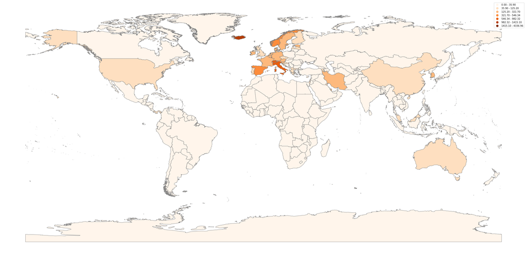

```python
world_shp_with_population_and_cases.plot(column='cases_per_milion', legend=True, \
                                         scheme='fisherjenks', k=7, cmap='Oranges',\
                                         figsize=(40, 40), edgecolor='grey', linewidth=1);
plt.axis('off');
```

If you want to download the project, visit my github: https://github.com/przemyslawmagiera/diy-coronavirus-map.

Thanks for reading!